# Predição de Votação de Deputados

Juan Barros

29 de outubro de 2018

Para iniciar a predição, é preciso limpar e tratar os dados para se adequarem aos modelos que utilizaremos. Como referência, usarei os parâmetros utilizados na [análise anterior](https://rpubs.com/JuanBarros/lab2). A seguir, realizo a importação e tratamento dos dados de treino disponível:

```r
dadosBrutos <- read.csv("train.csv") # Ao utilizar read_csv, o caret emite um erro
teste <- read.csv("test.csv") %>%
  mutate(comites = recursos_de_outros_candidatos.comites)
dadosLimpos <- dadosBrutos %>%
  mutate(comites = recursos_de_outros_candidatos.comites) %>%
  select(-sequencial_candidato, -uf, -partido, - estado_civil, -ano, -recursos_de_outros_candidatos.comites)
```

Para realizar o treino no modelo ridge, utilizarei o comando “train”" do caret para treinar meu modelo com o parâmetro “lambdas”, que descreve valores de lambda para a utilização no treino.

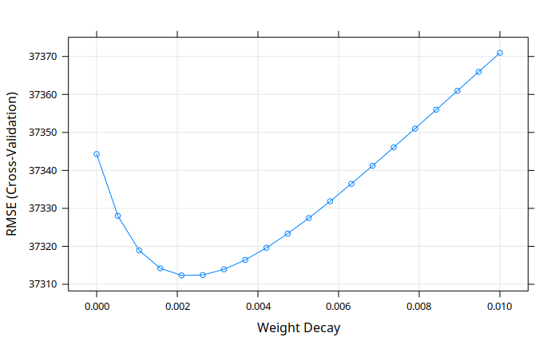

```r
lambdas <- expand.grid(lambda = seq(10^-2, 10^-9, length=20))
validacaoCruzada <- trainControl(method = "cv", number = 10)
ridgeModel <- train(votos ~ media_despesa + total_despesa + quantidade_fornecedores + quantidade_despesas + recursos_de_partido_politico + recursos_proprios + recursos_de_pessoas_juridicas + recursos_de_pessoas_fisicas + comites + media_receita + total_receita + quantidade_doadores + quantidade_doacoes, data = dadosLimpos,
                 method = "ridge",
                 tuneGrid = lambdas, preProc = c("center", "scale"),
                 trControl = validacaoCruzada)
plot(ridgeModel)
```

```r
ridgeModel
```

```
Ridge Regression

7476 samples
  13 predictor

Pre-processing: centered (13), scaled (13)
Resampling: Cross-Validated (10 fold)
Summary of sample sizes: 6728, 6728, 6729, 6729, 6728, 6728, ...
Resampling results across tuning parameters:

  lambda        RMSE      Rsquared   MAE
  0.0000000010  37344.30  0.4043681  16865.21
  0.0005263167  37328.03  0.4045881  16867.90
  0.0010526325  37318.94  0.4046947  16870.16
  0.0015789482  37314.21  0.4047303  16871.97
  0.0021052639  37312.35  0.4047184  16873.47
  0.0026315797  37312.45  0.4046739  16874.97
  0.0031578954  37313.93  0.4046065  16876.21
  0.0036842112  37316.41  0.4045231  16877.35
  0.0042105269  37319.61  0.4044282  16878.45
  0.0047368426  37323.34  0.4043254  16879.35
  0.0052631584  37327.45  0.4042170  16880.05
  0.0057894741  37331.86  0.4041051  16880.60
  0.0063157898  37336.46  0.4039910  16881.39
  0.0068421056  37341.22  0.4038757  16882.16
  0.0073684213  37346.08  0.4037601  16882.77
  0.0078947371  37351.01  0.4036448  16883.22
  0.0084210528  37355.98  0.4035301  16883.53
  0.0089473685  37360.97  0.4034166  16883.71
  0.0094736843  37365.97  0.4033044  16883.77
  0.0100000000  37370.95  0.4031937  16883.81

RMSE was used to select the optimal model using the smallest value.
The final value used for the model was lambda = 0.002105264.
```

Para o modelo lasso, mudarei apenas o parâmetro que define o método e o range do lambda:

```r
lambdas <- expand.grid(fraction = seq(0.01, 10^-8, length=20))
lassoModel <- train(votos ~ media_despesa + total_despesa + quantidade_fornecedores + quantidade_despesas + recursos_de_partido_politico + recursos_proprios + recursos_de_pessoas_juridicas + recursos_de_pessoas_fisicas + comites + media_receita + total_receita + quantidade_doadores + quantidade_doacoes, data = dadosLimpos,
                 method = "lasso",
                 tuneGrid = lambdas,
                 preProc = c("center", "scale"),
                 trControl = validacaoCruzada)

plot(lassoModel)
lassoModel
```

[output not shown]

Por fim, no modelo KNN o parâmetro que indicará a quantidade de vizinhos será o k:

```r
k <- expand.grid(k = seq(20, 100, length=81)) # O pacote de treino lerá a coluna "k" para extrair o valor dos vizinhos

knnModel <- train(votos ~ media_despesa + total_despesa + quantidade_fornecedores + quantidade_despesas + recursos_de_partido_politico + recursos_proprios + recursos_de_pessoas_juridicas + recursos_de_pessoas_fisicas + comites + media_receita + total_receita + quantidade_doadores + quantidade_doacoes,
                     data = dadosLimpos,
                     method = "knn",
                     trControl = validacaoCruzada,
                     preProcess = c("center","scale"),
                     tuneGrid = k)

plot(knnModel)
knnModel
```

[output not shown]

# Compare os três modelos em termos do erro RMSE de validação cruzada

```r
summary(resamples(list(RIDGE= ridgeModel, LASSO = lassoModel, KNN = knnModel)))
```

```
Call:
summary.resamples(object = resamples(list(RIDGE = ridgeModel, LASSO = lassoModel, KNN = knnModel)))

Models: RIDGE, LASSO, KNN
Number of resamples: 10

MAE
          Min.  1st Qu.   Median     Mean  3rd Qu.     Max. NA's
RIDGE 14900.14 15993.53 16782.41 16873.47 17983.76 18471.07    0
LASSO 16602.92 16775.63 16924.54 17179.63 17439.08 18504.70    0
KNN   10329.55 11197.37 11914.89 11871.43 12538.84 13378.91    0

RMSE
          Min.  1st Qu.   Median     Mean  3rd Qu.     Max. NA's
RIDGE 26522.23 30416.74 36395.84 37312.35 39520.90 57970.08    0
LASSO 28426.85 31282.29 35342.64 37807.64 41639.35 59994.41    0
KNN   22054.97 24978.09 29665.29 31784.33 35897.58 55216.22    0

Rsquared
           Min.   1st Qu.    Median      Mean   3rd Qu.      Max. NA's
RIDGE 0.1877535 0.3538361 0.4210408 0.4047184 0.4729039 0.6012685    0
LASSO 0.2169974 0.3321692 0.4338760 0.4009839 0.4775980 0.5000270    0
KNN   0.3439027 0.5030848 0.5665724 0.5591107 0.6538928 0.6921733    0
```

# Quais as variáveis mais importantes segundo o modelo de regressão Ridge e Lasso? Variáveis foram descartadas pelo Lasso? Quais?

```r
ridgeImp <-ggplot(varImp(ridgeModel))
lassoImp <-ggplot(varImp(lassoModel))
grid.arrange(ridgeImp, lassoImp, nrow = 1)
```

[output not shown]

```r
preditores <- predictors(lassoModel)
preditores
```

[output not shown]

Todas as outras variáveis foram eliminadas.

# Re-treine o melhor modelo (usando os melhores valores de parâmetros encontrados em todos os dados, sem usar validação cruzada)

Para retreinar, removerei todas as variáveis desnecessárias de acordo com o valor obtido na questão anterior.

```r
dadosAdaptados <- dadosLimpos %>%
  select(preditores, votos)
```

Em seguida, retreinarei o modelo knn tendo em vista seu baixo RMSE:

```r
knnModelMelhorado <- train(votos ~ .,
                     data = dadosAdaptados,
                     method = "knn",
                     trControl = validacaoCruzada,
                     preProcess = c("center","scale"),
                     tuneGrid = k)


plot(knnModelMelhorado)
knnModelMelhorado
```

[output not shown]

# Use esse último modelo treinado para prever os dados de teste disponíveis [no challenge que criamos na plataforma Kaggle](https://www.kaggle.com/c/ufcg-cdp-20182)

```r
previsao <- predict(knnModelMelhorado, teste)
resposta <- data.frame(ID= teste$sequencial_candidato, votos= previsao)
resposta$ID <- as.character(resposta$ID)
```